# cssS-LB_DSM-epi_analysis_walkthrough

Kenyon

January 11, 2016

### 1. Location of gcfile with growth rate measurements

```r
dat_name<-"LB"
media<-"LB"

gcfile<-read.csv("C:/Users/Kenyon/Documents/Bacillus_subtilis/Growth Rates/Eon data/DSM-LB-2rowseach+cssS/LB-gcfit-repsavgd2016-02-01.csv")
gcfile<-gcfile[,-1]
gcfile<-gcfile[-which(is.na(gcfile$strain)),]
```

### 2. Create stacked version of data:

Use “GRdata_collect_heirarch.R”, which creates a stacked version of data

Header of stacked version of data:

```
##           assay media  plate well    AM373       CM       CN     CssS     McpA       MN     NhaK
## 1 lambda.spline    LB 23-Sep DEF3 2.814150 3.181705 3.407186 3.246267 3.249815 3.336473 3.277331
## 2 lambda.spline    LB 25-Sep DEF9 3.335698 3.344211 3.531202 3.489394 3.468888 3.129193 3.279445
## 3 lambda.spline    LB  7-Oct DEF8 2.847147 3.216664 3.311922 3.252708 3.058705 3.339823 3.222016
## 4 lambda.spline    LB  9-Oct DEF7 3.029414 3.027555 3.099893 3.205185 3.043254       NA 2.888222
## 5 lambda.spline    LB 12-Oct DEF6 2.812470 3.012485 3.405567 3.227154 3.080507 3.073170 3.084407
## 6 lambda.spline    LB 14-Oct DEF4 2.616118 3.198934 3.217766 3.251597 3.027045 3.064013 3.186380
```

### 3. Plot of pre-normalized measurements, using errort.bars function:

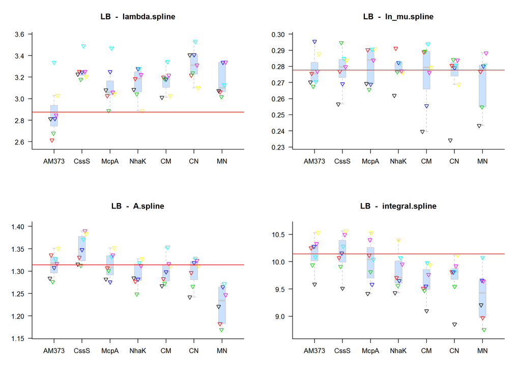

```
## [1] "units on y-axis of figures:  lambda.spline (hrs), ln_mu.spline (ln(OD)/hr), A.spline (OD600), integral.spline (OD*hrs)"
```

```
##                        meas    strains    difs perc_dif    pvals p05
## CM-AM373      lambda.spline   CM-AM373  0.2900   0.1010 8.12e-04   *
## CN-AM373      lambda.spline   CN-AM373  0.4400   0.1530 6.37e-07   *
## CssS-AM373    lambda.spline CssS-AM373  0.3880   0.1230 7.47e-06   *
## McpA-AM373    lambda.spline McpA-AM373  0.2400   0.0836 7.67e-03   *
## MN-AM373      lambda.spline   MN-AM373  0.2680   0.0930 3.68e-03   *
## NhaK-AM373    lambda.spline NhaK-AM373  0.2640   0.0833 2.70e-03   *
## McpA-CN       lambda.spline    McpA-CN -0.1990  -0.0692 4.20e-02   *
## NhaK-CN       lambda.spline    NhaK-CN -0.1760  -0.0554 9.95e-02
## CssS-AM3732        A.spline CssS-AM373  0.0361   0.0278 1.09e-02   *
## MN-AM3732          A.spline   MN-AM373 -0.0817  -0.0622 2.96e-08   *
## CssS-CM2           A.spline    CssS-CM  0.0500   0.0381 1.80e-04   *
## MN-CM2             A.spline      MN-CM -0.0678  -0.0516 1.67e-06   *
## CssS-CN2           A.spline    CssS-CN  0.0520   0.0400 9.81e-05   *
## MN-CN2             A.spline      MN-CN -0.0658  -0.0501 2.99e-06   *
## McpA-CssS2         A.spline  McpA-CssS -0.0379  -0.0288 6.64e-03   *
## MN-CssS2           A.spline    MN-CssS -0.1180  -0.0897 2.32e-12   *
## NhaK-CssS2         A.spline  NhaK-CssS -0.0572  -0.0440 1.94e-05   *
## MN-McpA2           A.spline    MN-McpA -0.0799  -0.0609 4.91e-08   *
## NhaK-MN2           A.spline    NhaK-MN  0.0606   0.0466 1.42e-05   *
## CM-AM3733   integral.spline   CM-AM373 -0.5260  -0.0519 3.61e-04   *
## CN-AM3733   integral.spline   CN-AM373 -0.4440  -0.0439 3.27e-03   *
## MN-AM3733   integral.spline   MN-AM373 -0.6740  -0.0665 1.20e-05   *
## NhaK-AM3733 integral.spline NhaK-AM373 -0.3190  -0.0332 6.73e-02
## CssS-CM3    integral.spline    CssS-CM  0.5240   0.0517 3.76e-04   *
## McpA-CM3    integral.spline    McpA-CM  0.3690   0.0384 2.19e-02   *
## CssS-CN3    integral.spline    CssS-CN  0.4430   0.0461 3.40e-03   *
## MN-CssS3    integral.spline    MN-CssS -0.6720  -0.0663 1.25e-05   *
## NhaK-CssS3  integral.spline  NhaK-CssS -0.3180  -0.0331 6.95e-02
## MN-McpA3    integral.spline    MN-McpA -0.5170  -0.0510 8.08e-04   *
## NhaK-MN3    integral.spline    NhaK-MN  0.3540   0.0369 4.23e-02   *
```

| feature | description |
| --- | --- |
| Lag | All KOs have longer lag than AM373 (~10%); CN has longest lag (similar to in Triton-X) |
| Growth rate | All appear very similar; none significantly different (similar to in Triton-X) |
| A | CssS - higher than all other strains (2%), MN - significantly smaller than all other strains (4%) (similar to in Triton-X) |

### 4. Look for stat. sig. epistatic phenotypes

Following process in “epistasis_analysis-2015-12-07.R”:

#### a. Normalize data:

> in this document, all values are simply divided by the AM373 values because it is the only strain present in all sets; but if we are just looking at the TritonX set, then can divide by average within each day

Normalized data, header of table all replicates of all measurements:

```
##           assay media  plate well  AM373  CssS   McpA   NhaK     CM    CN     MN
## 1 lambda.spline    LB 23-Sep DEF3 0.8750 1.009 1.0100 1.0190 0.9893 1.059 1.0370
## 2 lambda.spline    LB 25-Sep DEF9 0.9903 1.036 1.0300 0.9736 0.9929 1.048 0.9290
## 3 lambda.spline    LB  7-Oct DEF8 0.8958 1.023 0.9623 1.0140 1.0120 1.042 1.0510
## 4 lambda.spline    LB  9-Oct DEF7     NA    NA     NA     NA     NA    NA     NA
## 5 lambda.spline    LB 12-Oct DEF6 0.9074 1.041 0.9939 0.9952 0.9720 1.099 0.9915
## 6 lambda.spline    LB 14-Oct DEF4 0.8493 1.056 0.9827 1.0340 1.0390 1.045 0.9947
```

#### b. Mean and sd of each assay level:

```
## [1] "average value of all replicates of each assay & strain:"
```

```
##             assay media num AM373  CssS  McpA  NhaK    CM    CN    MN
## 1   lambda.spline    LB   7 0.900 1.035 0.989 1.007 1.009 1.060 1.000
## 2    ln_mu.spline    LB   7 1.003 1.006 1.010 1.012 0.994 0.993 0.982
## 3        A.spline    LB   7 1.010 1.038 1.008 0.994 1.002 1.001 0.947
## 4 integral.spline    LB   7 1.032 1.031 1.013 0.997 0.979 0.986 0.961
```

```
## [1] "table of percent differences of each mutant strain from AM373:"
```

```
##             assay media num   CssS   McpA   NhaK     CM     CN     MN
## 1   lambda.spline    LB   7  0.150  0.099  0.119  0.121  0.178  0.111
## 2    ln_mu.spline    LB   7  0.003  0.007  0.009 -0.009 -0.010 -0.021
## 3        A.spline    LB   7  0.028 -0.002 -0.016 -0.008 -0.009 -0.062
## 4 integral.spline    LB   7 -0.001 -0.018 -0.034 -0.051 -0.045 -0.069
```

```
## [1] "table of st. dev. associated with each value in above table:"
```

```
##             assay media num  CssS  McpA  NhaK    CM    CN    MN avg_sd
## 1   lambda.spline    LB   7 0.019 0.032 0.023 0.033 0.024 0.047  0.030
## 2    ln_mu.spline    LB   7 0.033 0.037 0.019 0.050 0.037 0.038  0.036
## 3        A.spline    LB   7 0.008 0.016 0.009 0.009 0.013 0.021  0.012
## 4 integral.spline    LB   7 0.007 0.022 0.011 0.009 0.019 0.036  0.017
```

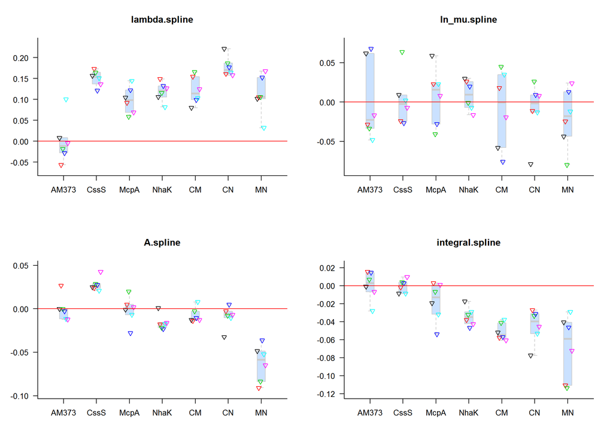

#### c. Calculate estimated value of double mutants from the single mutants, and whether the measure phenotypes of the double mutants are sig dif from that estimate

Use function ‘epi_func’, not shown in report but provided in markdown file

## CM:

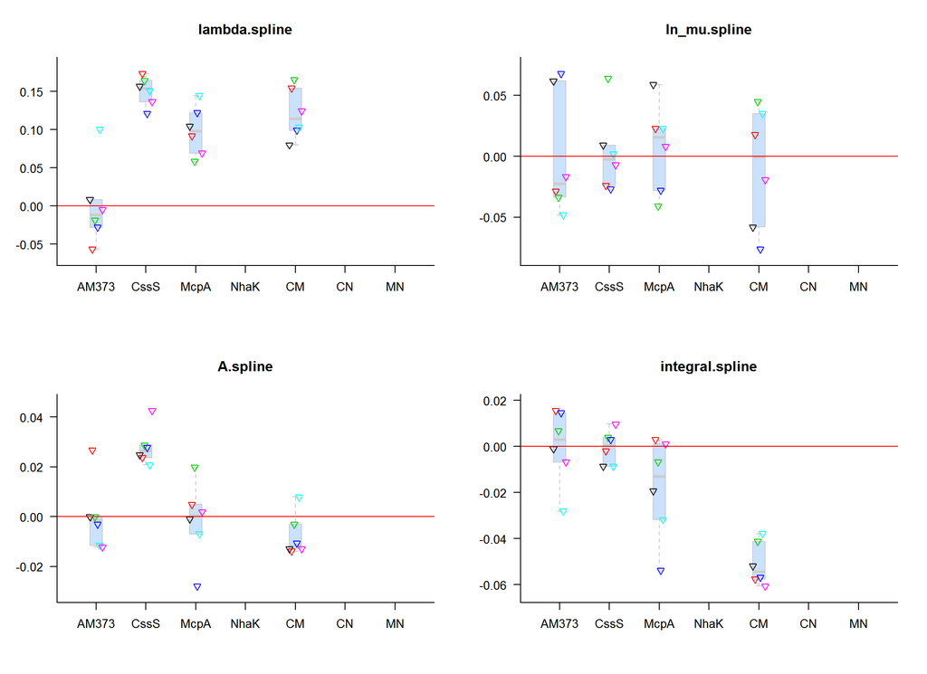

```
##             assay media     CssS     McpA       CM     dbl  t.test wil.test sig
## 1   lambda.spline    LB  0.15300  0.09990  0.12400  0.2530 0.00158   0.0312   *
## 2    ln_mu.spline    LB  0.00495  0.00886 -0.00561  0.0138 0.24700   0.3120
## 3        A.spline    LB  0.02820 -0.00140 -0.00735  0.0268 0.01520   0.0312   *
## 4 integral.spline    LB -0.00046 -0.01790 -0.05090 -0.0184 0.03720   0.0625   *
```

**CM: 2 Epistatic interactions found!** -

*Lag:* Phenotype of double is between value of singles (+12% vs 10%+15%) C & M have AM373 phenotype CM’s A.spline is significantly lower (2.3%) max OD than expected from single mutants (0.2%)  
**antagonistic epistasis** perhaps both KOs effect same mech, so functional loss redundant in double KO

*maxA:* CM and McpA have ~AM373 (no change), while CssS has +2% peak maxOD **caution**: could be due to cssS-specific mutation, CM derived from McpA

## CN:

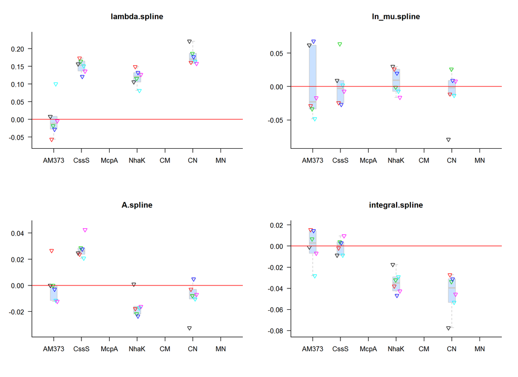

```
##             assay media     CssS     NhaK       CN     dbl t.test wil.test sig
## 1   lambda.spline    LB  0.15300  0.12200  0.18000  0.2750 0.0459   0.0625   *
## 2    ln_mu.spline    LB  0.00495  0.00983 -0.00765  0.0148 0.3870   0.5620
## 3        A.spline    LB  0.02820 -0.01570 -0.00914  0.0125 0.1150   0.1560
## 4 integral.spline    LB -0.00046 -0.03420 -0.04470 -0.0346 0.5080   0.6880
```

**CN: 1 Epistatic interaction, Lag** -

*Lag:* Phenotype of CN is higher than both C & N, but not as high as additively predicted **antagonistic epistasis**

## MN:

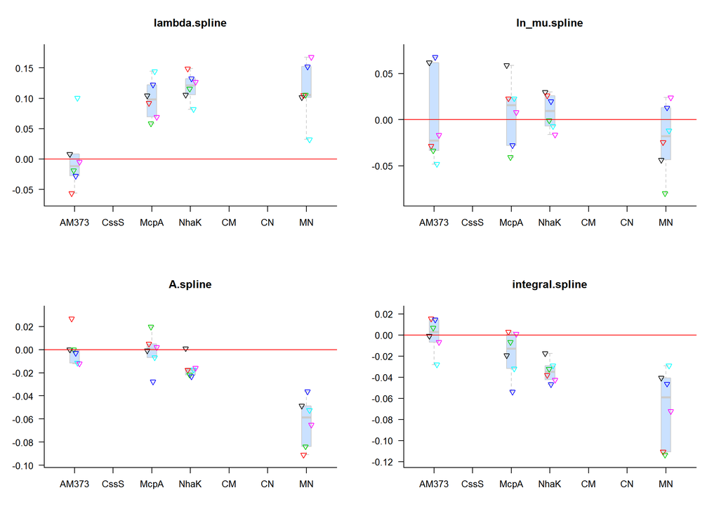

```
##             assay media     McpA     NhaK      MN     dbl  t.test wil.test sig
## 1   lambda.spline    LB  0.09990  0.12200  0.1150  0.2220 0.00589   0.0312   *
## 2    ln_mu.spline    LB  0.00886  0.00983 -0.0191  0.0187 0.25500   0.4380
## 3        A.spline    LB -0.00140 -0.01570 -0.0625 -0.0171 0.01700   0.0625   *
## 4 integral.spline    LB -0.01790 -0.03420 -0.0683 -0.0521 0.46200   0.5620
```

**MN: 2 Epistatic interactions found!** -

*Lag:* **antagonistic epistasis**: Phenotype of double is between value of singles (+11% vs 10%+12%) M & N have AM373 phenotype

*maxA:* **synergistic epistasis** Both M and N not sig lower (-1%) than AM373, while MN is -4% lower maxOD

**why wasn’t this noticed before?**: due to mutations acquired since big thaw?